# Visualizations in R

March 28, 2018

Today we are going to talk about how to visualize data in R. There are multiple packages that can be used for this, including base R. Base R has all the tools and functions needed to effectively communicate results. That said, more recent packages offer a more modular approach to building visualizations using a *grammer of graphics*. This class will focus on using the `ggplot2` library for plotting and visualizations.

`ggplot2` is developed as part of the `tidyverse`, and loads as a base component of the library.

`r`r library(tidyverse)

[output not shown]

## A Simple Plot

Let’s first make a sequence of data to work with.

`r`r # three sequences of data x <- seq(0,1, by=0.1) y <- x y2 = x^2

Being a part of the `tidyverse` means `ggplot2` works best with *tidy data*. For convenience and consistency, `ggplot2` expects the data as a data frame so we can access all the variables within it. So, put the data into a data frame, or a tibble in this case.

| x | y | y2 |
| --- | --- | --- |
| 0.0 | 0.0 | 0.00 |
| 0.1 | 0.1 | 0.01 |
| 0.2 | 0.2 | 0.04 |
| 0.3 | 0.3 | 0.09 |
| 0.4 | 0.4 | 0.16 |
| 0.5 | 0.5 | 0.25 |
| 0.6 | 0.6 | 0.36 |
| 0.7 | 0.7 | 0.49 |
| 0.8 | 0.8 | 0.64 |
| 0.9 | 0.9 | 0.81 |

[output cut: 1 more lines]

### Constructing the Plot

One of the most powerful aspects of `ggplot2` is the ability to quickly generate multiple types of visualizations using the same data object. The base element in a call to `ggplot2` is the constructor, `ggplot()`, which creates an element with the data.

The basic syntax for `ggplot2` is to *add* elements to the the base object:

Data Object + mappings(color, size, shape) + geometry = plot

The only **required** argument is `data`. A secondary, but not strictly required, argument is `aes()`, or aesthetics (plotting variables) to use. These are the actual columns of data to apply in the plot and how to visualize them (e.g. color or size). The call to `aes()` is used in different ways based on the context or the object. Different calls to `aes()` can be made in different plot elements. You will see that in a moment.

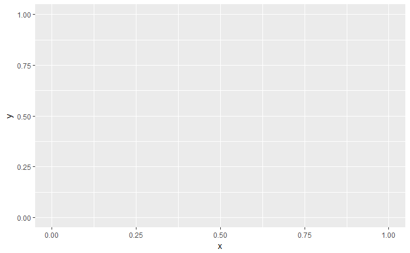

The plot object above is a blank page. There is no geometry associated with the data, so ggplot does not know what to visualize. That will be the next step.

We are assigning the results of the call to `ggplot()` a variable in the example above. While this is not necessary, it does allow us to reuse the base object to build different plots. We can see how to build a plot without assigning it to a variable in a minute.

`ggplot2` uses *geometries* to describe the different types of visualizations to apply to the data. Geometries refer to plot types like: bars, points, lines, etc. Again, we can apply different types of geometries to the same base object, but they do need to be related.

Now that we have a base plot object, we can apply various geometries. We need to add all the elements, which can be very detailed and fine-tuned. Let’s break down the plot element-by-element, *adding* one at a time.

Start with the base data object, adding a point to each element.

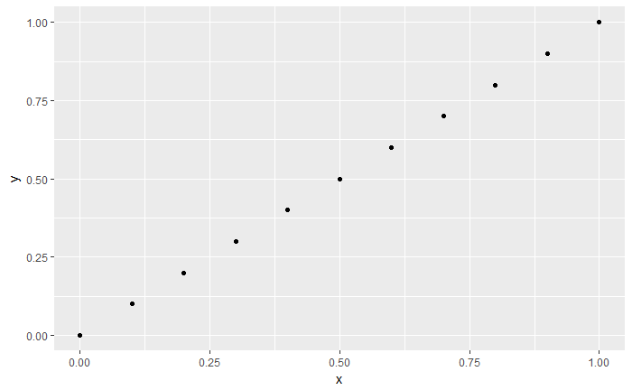

Notice that the call above did not assign the output to a new variable; we simply generated the plot using the base data object and assigning the aesthetics to a point geometry. We can easily assign the output to a variable for use later or to save, but it’s not necessary if you only want to see the plot.

Now *add* a title:

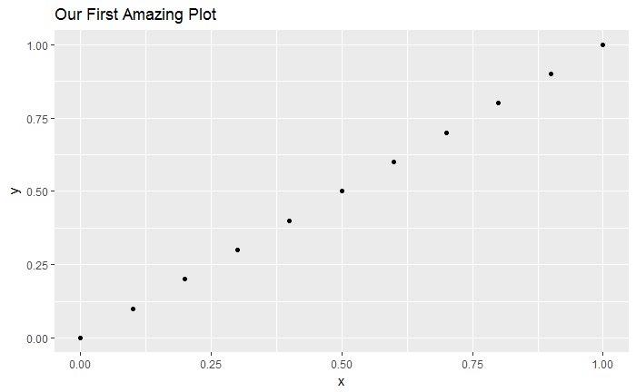

Great, but we can fine-tune the plot, *adding* elements like axis labels.

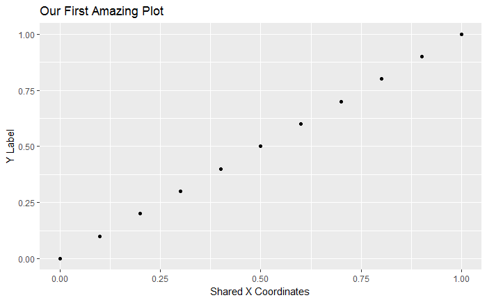

We can also change the basic theme of the plots to one of the bulit in verions. If you are feeling adventurous, you can also find libraries with custom themes. Check out ggthemes

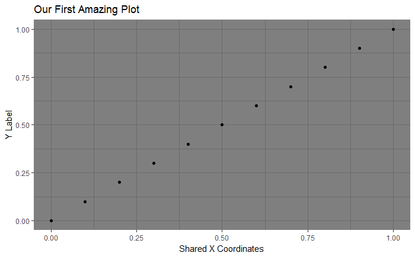

`ggplot2` also supports multiple geometries on the same plot as long as the data share a common coordinate system and range. Scales can also be added for a shared axis with a different range of values to accomodate different datasets (e.g. temperature and precipitation), but that’s more advanced. For now let’s *add* a second variable with a shared axis.

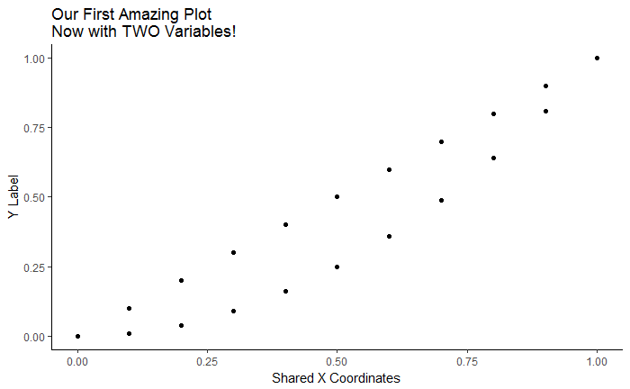

Now that we have visualized several elements, we can learn how to further refine elements of the plot. For example, we can add color and size to some points, and add a new line.

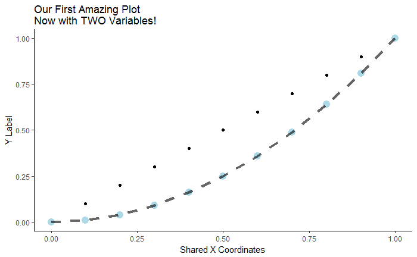

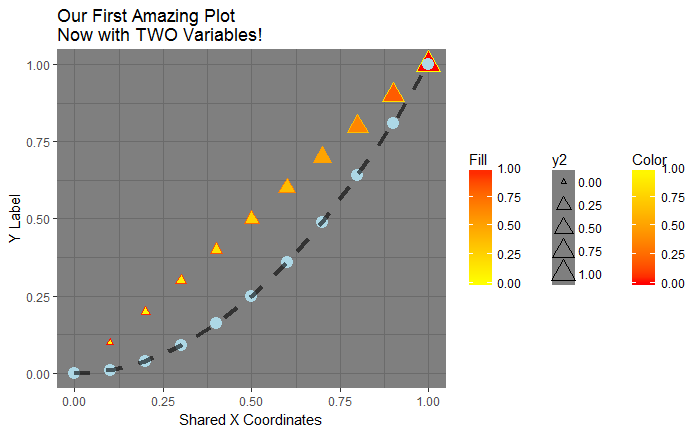

An important note regarding scale_ (gradient, fill, etc.) functions. `ggplot2` current only support ONE scale_ per geometry. That means that the colors and fill gradients assigned to the plot the first point geometry is the only one available, and we CANNOT assign a new color ramp to the second set of point values. New geometries will inherit the last color used, which can lead to some confusion about what is happening. We can reuse the same scale_ value for BOTH sets. We can also assign new value for other geometries (the lines for example).

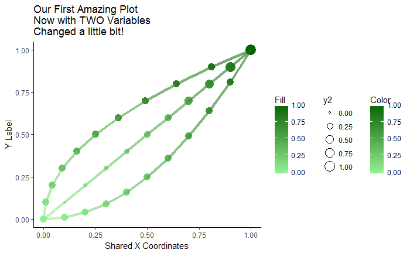

There are workarounds for making this work (google that if you want to try). The better, but complex, solution is to combine your variables in some way and add a categorical variable that can be used to stratify the data. This is an advanced topic that won’t be covered here.

This example only touches the surface of the extent of customization available in `ggplot2`. Just about every aspect of every geometry can be modified to accomodate the exact position, shape, name, color, etc. of your data. But, the base elements of `ggplot2` and the ease of construction make visualizing your results very easy and pleasing to the eye.